[figure not shown]

# **tdaunif**: Uniform manifold samplers for topological data analysis

This R package consists mainly of sampling functions for topological manifolds embedded in Euclidean space.

## motivation

### consolidation

Statistical topology, or topological data analysis (TDA), includes a variety of methods for detecting topological structure from point cloud data sets, most famously persistent homology. (See [Weinberger (2011)](https://www.ams.org/notices/201101/rtx110100036p.pdf) for a brief introduction.) These methods are validated by applying them to point clouds sampled from spaces with known topology. Functions that generate such samples are therefore valuable to developers of TDA software.

Unfortunately, such samplers are not currently easy to find, at least for R users. Handfuls can be found in several different packages, but no single package or code repository has assembled a large collection for convenient use. That is the goal of this package.

### uniformity

The simplest validations use points sampled uniformly from the surfaces of manifolds embedded in Euclidean space. Uniformity here is with respect to the surface area of the embedded manifold, but such uniform sampling is not trivial to do when the manifold can only be expressed via parameterization from a simpler parameter space, as when [a square is rolled and bent into a torus](https://en.wikipedia.org/wiki/Torus#Flat_torus). Uniform sampling on the parameter space may then produce uneven sampling on the manifold, regions of greater compression being oversampled relative to regions of greater expansion. One especially important motivation for this package is therefore to include uniform samplers for popular embeddings of topological manifolds, including functions that allow users to build their own with minimal effort (see `help(manifold, package = "tdaunif")`).

## usage

### installation

**tdaunif** is not yet on CRAN, but you can install it from GitHub using [the **remotes** package](https://github.com/r-lib/remotes):

```r
remotes::install_github("corybrunson/tdaunif")
```

### illustration

[An intuitive embedding of the Klein bottle into 4-space](https://en.wikipedia.org/wiki/Klein_bottle#3D_pinched_torus_/_4D_M%C3%B6bius_tube) is adapted from the popular “donut” embedding of the torus in 3-space. In **tdaunif** this is called the “tube” parameterization. We can sample uniformly from this embedding (without noise) and examine the coordinate projections as follows:

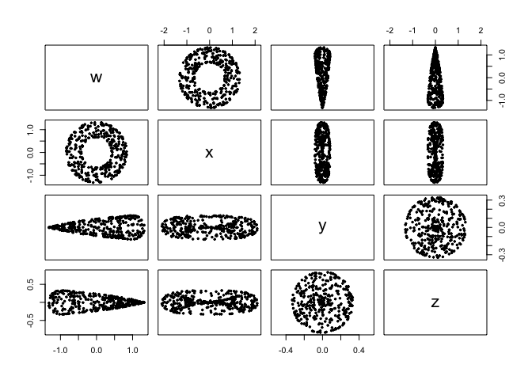

```r
set.seed(0)
x <- sample_klein_tube(n = 360, ar = 3, sd = 0)
pairs(x, asp = 1, pch = 19, cex = .5)
```

Compare these neat projections to those of the same sample with noise added in the ambient Euclidean space:

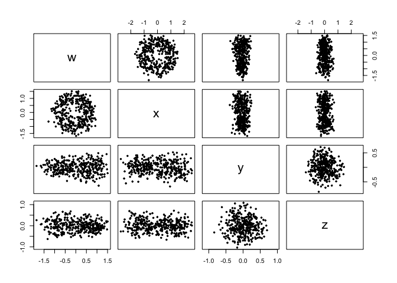

```r
x <- add_noise(x, sd = .2)
pairs(x, asp = 1, pch = 19, cex = .5)
```

For a thorough discussion of this sampler, see [my blog post](https://corybrunson.github.io/2019/02/01/uniform-sample-embedded-klein-bottle/) describing the method presented in [Diaconis, Holmes, and Shahshahani (2013)](https://projecteuclid.org/euclid.imsc/1379942050).